# Expanding the Game

It’s time to expand what we have and create content for our game. New monsters, new towers, in game events, let’s put our systems to test!

In this lesson we’ll: - Build new towers - Design new enemies - Bundle enemies into new waves - Use events to tell a story - Create level progression - Show an end screen with the score

This is a fundamental part of game development. Because Godot is a general use game engine, it doesn’t provide the specifics to create games of each genre. Instead, it offers a good general use code base and a good architecture.

It’s time to understand how to use our tower defense base to create our games.

## Creating new towers

Right now, we only have a basic tower; it only performs a simple role game-wise. It shoots enemies, has fixed damage and a fixed range. There isn’t much that the player can do with this and it limits their strategies.

Let’s change that! We create a tower that shoots bombs with area of effect damage.

We introduce the concept of inherited scenes. They follow the same principles of class inheritance, so be mindful with how you use them.

### Creating a bomb

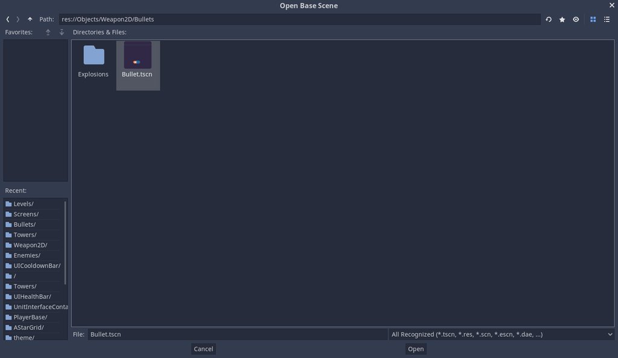

We end up with an inherited scene with all the features from the bullet. Any changes in the base bullet scene will sync with this scene. Let’s save this one as `res://Objects/Weapon2D/Bullets/BombBullet.tscn`.

Change the *Sprite > TextureRect* to match the one that represents a bomb in the sprite sheet.

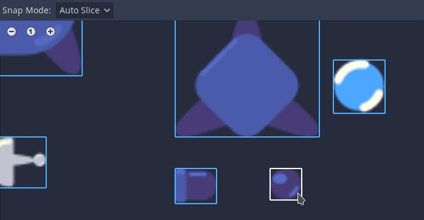

As the bomb doesn’t use any thrust to move, hide the other *Sprite* that represents the thrust’s fire.

For better visualization, scale up the *Sprite* so that the bomb looks bigger relative to a bullet. Set the *Sprite > Scale* to `1.3` in both axes.

Since the bomb will cause area of effect damage, we use a different shape for its hit area. In the *HitBoxArea2D > CollisionShape2D > Shape* property, create a new *Circle2D* shape and define a good radius for it. A radius of `64.0` should do the trick.

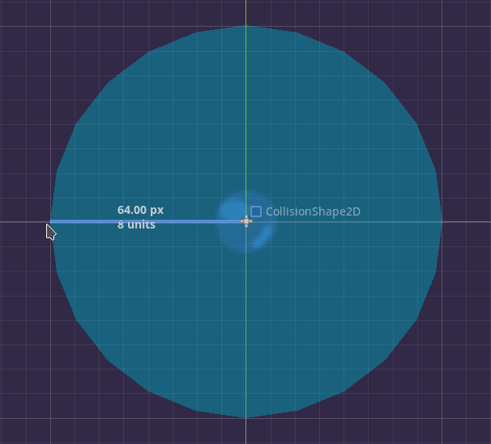

Because the bomb does area of effect damage, it should hit multiple enemies at once, so toggle on the *HitBoxArea2D > Can Hit Multiple* property. To balance things out, decrease its damage to `2`. If it manages to hit two enemies, it’s already caused more total damage than a simple bullet.

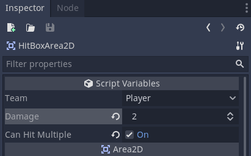

By design, it should only hit enemies if they are inside its explosion area *when it explodes*. When the bomb appears, it shouldn’t cause any damage to enemies until it reaches its target position and explodes.

This bomb needs to explode! In the `res://VFX/Explosion/` folder you can find our `Explosion.tscn` effect. Instance it as child of the bomb. We use this effect instead of the *SmallExplosion*, so toggle off the latter’s visibility.

This is how the `SceneTree` should look like at moment.

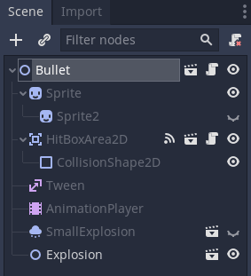

We use the *AnimationPlayer* to achieve that area of effect behavior. We have everything in place to design this behavior, so it’s just a matter of telling when each event happens.

Create a new animation, you can call it “SETUP”. Remember, the bomb shouldn’t deal damage until it explodes. Add a track that toggles on its *Disable* property. Toggle on the *Autoplay* button on the setup animation so it plays right when the bomb instances.

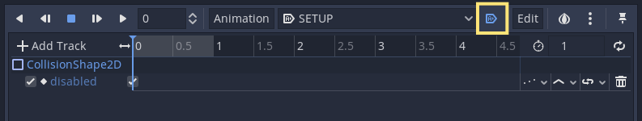

As for the explosion animation, we should have something in mind. As this is an inherited scene, it uses the same resources from the base scene. That means that if we change the current *Explosion* animation, this will reflect back in the base scene. We don’t want that.

To prevent that from happening, delete the explode animation, save the scene, and create a new animation named *Explode*. It should have this name due to the *Bullet* logic, which plays the `"Explode"` animation when it reaches its target position.

Now, for the bomb’s explosion animation, we have to start *Explosion* scene and grab its duration by getting information from its *AnimationPlayer*’s *Animation Playback Track*.

However, you may notice that we can’t access the *Explosion > AnimationPlayer*.

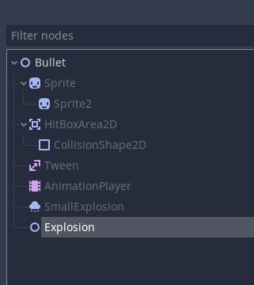

When we instance scenes in our scene hierarchy, we usually shouldn’t have access to their implementation details. This follows the same principles of encapsulation in object-oriented programming. We should only use what’s exposed to us, in this case through the *Inspector*.

But there’s a way to access children of an instanced scene. Right-click on the *Explosion* node and toggle on *Editable Children* to see its composition. We should use this feature with care to prevent any game breaking bugs.

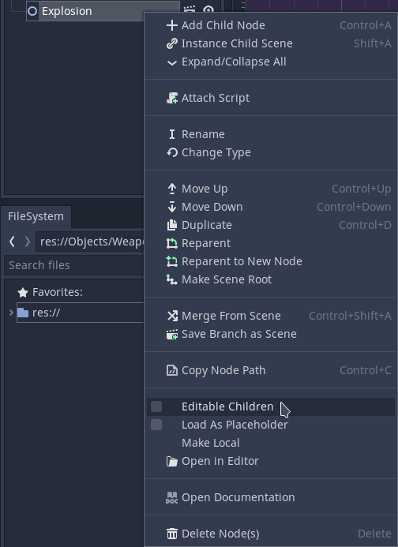

We are safe to do this because the *Explosion* doesn’t have any complex behavior, and it’s designed to have another object play its *Explode* animation.

We now we should have access to the *Explosion > AnimationPlayer* for our *Animation Playback Track*. Create the track and select it. When Godot creates the track, toggle off the *Explosion* *Editable Children*.

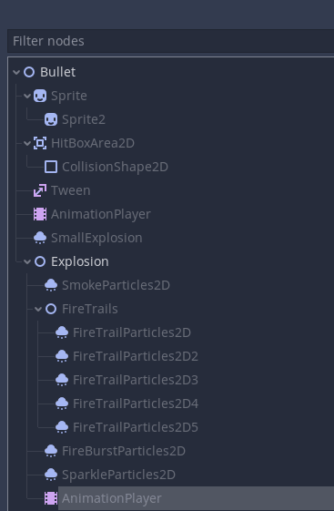

In the animation timeline, on the *Animation Playback Track* insert a new key and in the *Inspector* select the *Explode* animation. This will display a gray rectangle in the timeline. This is a rough representation of the explode animation. Match our animation to the explode animation’s length to `3.0` seconds.

As the bomb explodes, we toggle on its hit area. Select the *CollisionShape2D*, turn off its *Disable* property and insert a key in the bomb’s explode animation. The bomb shouldn’t keep hitting enemies forever, so we toggle on the *CollisionShape2D > Disable* as soon as it explodes. As soon as the debris disappear, we disable the *CollisionShape2D* at around `0.5` seconds.

After the bomb explodes and the smoke disappears, we delete the bomb. Add a *Call Method Track* and select the root node. At the end of the animation, insert a key calling the `queue_free()` method. This is the final bomb’s explode animation.

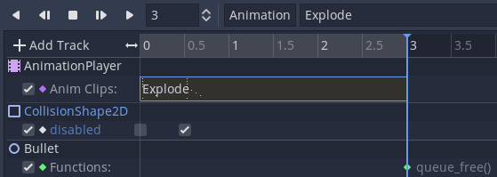

With a bomb to shoot, we can create our bomber!

### Creating a tower to shoot bombs

Let’s create a new tower to shoot bombs at those pesky enemies. We follow the same inheritance approach. Create a new inherited scene and use the `res://Objects/Towers/Tower.tscn` as base scene. Save it as `res://Objects/Towers/BombTower.tscn`.

Drag the `BombBullet.tscn` to the *Weapon2D > Bullet Scene* property. Functionally, that’s all we need to do. But let’s tweak the assets and balance it.

Toggle *Editable Children* on the *Weapon2D* and select the *Weapon2D > Sprite*. In the *TextureRegion* editor, select the cannon rect to differentiate the towers.

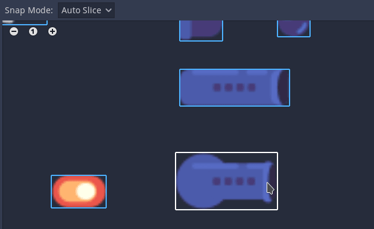

Change the *Sprite > Offset* to `36.0` in the `x` axis to position it better relative to the tower. We should also reposition the *BulletSpawnPosition* to match the cannon’s rear.

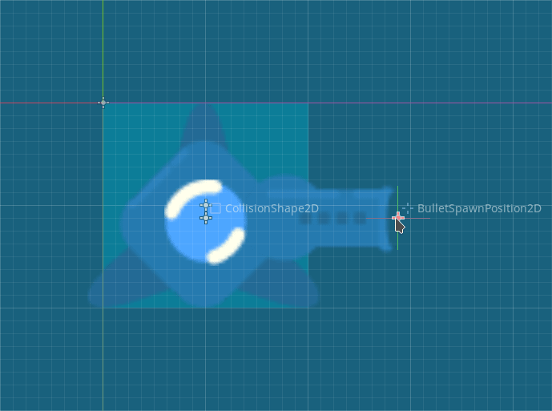

Time for balancing! Collapse the *Weapon2D*’s hierarchy to prevent the temptation of changing something else. In the *Inspector*, set the *Fire Range* to `128.0` and increase the *Fire Cooldown* to `3.0`.

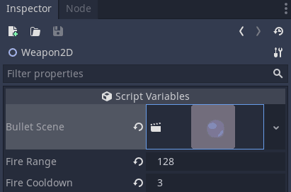

### Selling new towers

We should provide this new tower to players so they can buy and use it. `500` gold should be fair in exchange of those cool explosions! Change the *Tower > Cost* to `500`. Feel free to play with different prices to test out different strategies.

Open the `res://UI/UITowerShop/UITowerShop.tscn` so we can put the bomber in the tower shop.

Duplicate the *UITowerPurchaseButton* and drag the bomber scene to its *Tower Scene* property.

In the *UITowerPurchaseButton > Hint > Tooltip* add a nice description about the bomber like:

> Bomb tower. Shoots a bomb at a target position that hits every enemy inside its explosion area.

Save the scene and open the `res://Game.tscn` to test how the game looks like with the new tower.